# Portfolio Project First Deliverable

## Introduction

My research will be focused on the gender gap in computing and technology careers.I chose this topic because I want to bring awareness of the topic, and hopefully be a part of the solution to even out the statistics of women in technology and STEM careers. I have a very deep interest for this topic because I an a part of the very small percentage of hispanic women in Computer Science. As a part of this research I want to predict how the gender gap will hopefully decrese in future years.

## Data Set

The Data I will be using for this research is from the National Center for Women & Information Technology. NCWIT is a non-profit organization that works to increase the influence women have in the tech industry.

#### Variables in data set:

`year` `int` : States the year that was measured. From 1989 to 2017.

`women` `int` : Represents the number of women that have a degree in tech.

`men` `int` : Represents the number of men that have a degree in tech.

`perc_women_all_degrees` `double` : the percentage of women that have a degree in the tech field.

`perc_ men of all_degrees` `double` : the percentage of men that have a degree in the tech field.

`degree_type` `factor` : Variable used to describe what level of degree it is, AS for Associate’s, BS for Bachelor’s, MS for Master’s and PhD for a Doctorate’s.

`ethniciy_race` `factor` : Describes the Race and or ethnicity of the person.

```r
data <- read.csv('phase1.csv')
head(data)
```

|  | year | women | men | perc_women_all_degrees | perc_men_all_degrees | degree_type | ethniciy_race |
| --- | --- | --- | --- | --- | --- | --- | --- |
| 1 | 1989 | 1838 | 1137 | 0.004599703 | 0.002845409 | AS | native |
| 2 | 1990 | 1953 | 1246 | 0.004641193 | 0.002961048 | AS | native |
| 3 | 1991 | 2309 | 1354 | 0.005112422 | 0.002997930 | AS | native |
| 4 | 1992 | 2400 | 1324 | 0.005145268 | 0.002838473 | AS | native |
| 5 | 1993 | 2622 | 1482 | 0.005441674 | 0.003075729 | AS | native |
| 6 | 1994 | 2939 | 1732 | 0.005898124 | 0.003475860 | AS | native |

## Explanatory Data Analysis

This is a summary of the variables inside the data set

```r
summary(data)
```

```
##       year          women             men         perc_women_all_degrees
##  Min.   :1989   Min.   :    35   Min.   :    48   Min.   :0.0009693
##  1st Qu.:1996   1st Qu.:  2294   1st Qu.:  1569   1st Qu.:0.0152973
##  Median :2003   Median : 16058   Median : 12512   Median :0.0314563
##  Mean   :2003   Mean   : 67717   Mean   : 47849   Mean   :0.0959957
##  3rd Qu.:2010   3rd Qu.: 56378   3rd Qu.: 34391   3rd Qu.:0.0672998
##  Max.   :2017   Max.   :652589   Max.   :508000   Max.   :0.4746231
##  perc_men_all_degrees degree_type         ethniciy_race
##  Min.   :0.001187     AS :145     black          :116
##  1st Qu.:0.013543     BS :145     hispanic_latino:116
##  Median :0.023143     MS :145     native         :116
##  Mean   :0.071179     PhD:145     pacificIslander:116
##  3rd Qu.:0.034328                 white          :116
##  Max.   :0.392301
```

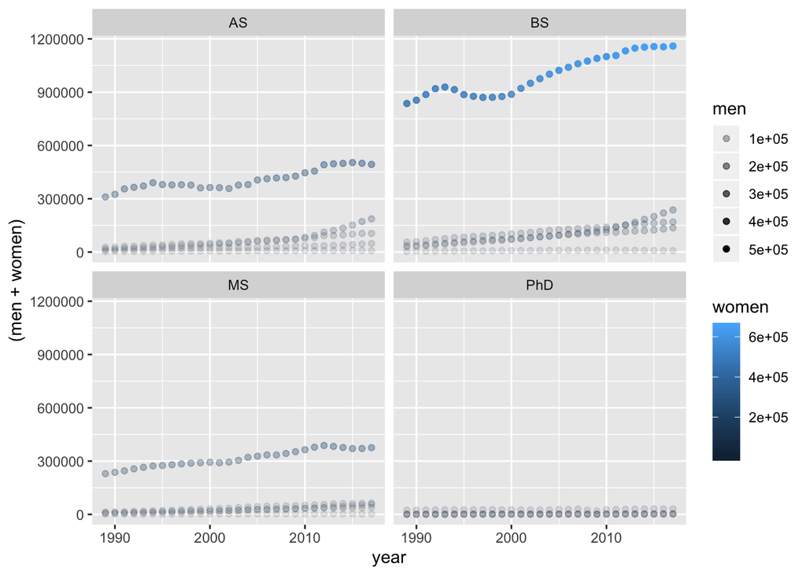

```r
ggplot(data) +
  geom_point(mapping = aes(x= year, y= (men + women), alpha = men, colour = women)) +
  facet_wrap(~(degree_type))
```

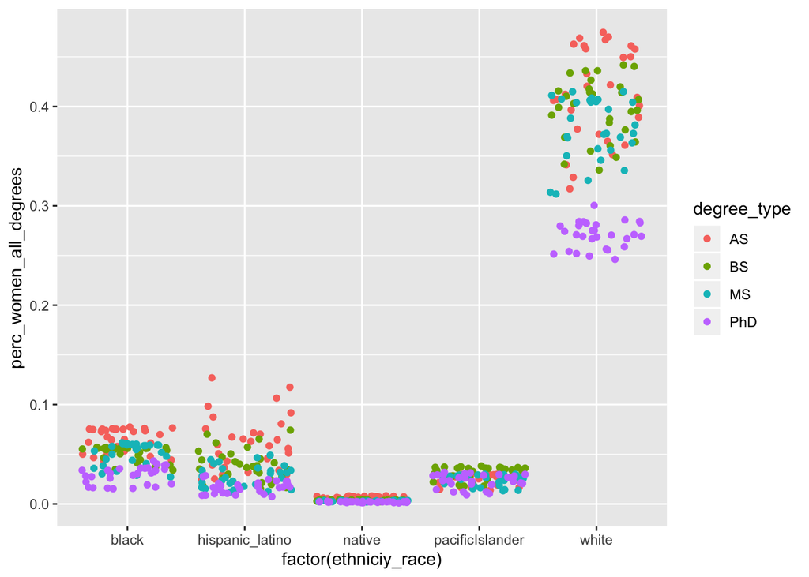

```r
ggplot(data, mapping = aes(factor(ethniciy_race), perc_women_all_degrees, colour = degree_type))+
  geom_jitter()
```

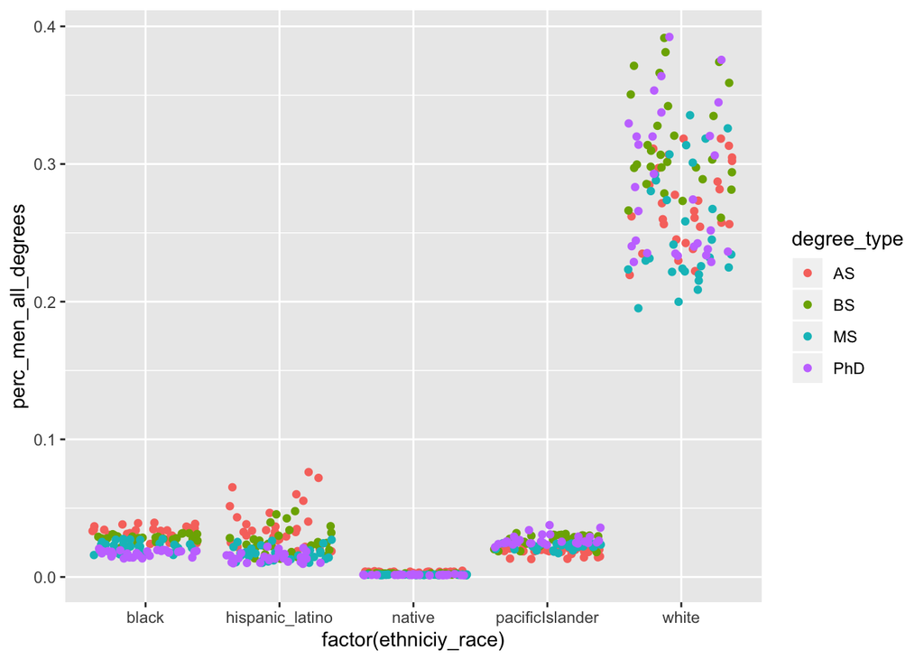

```r
ggplot(data, mapping = aes(factor(ethniciy_race), perc_men_all_degrees, colour = degree_type))+
  geom_jitter()
```

These graphs representes the racial composition of womenand men with degrees in tech.

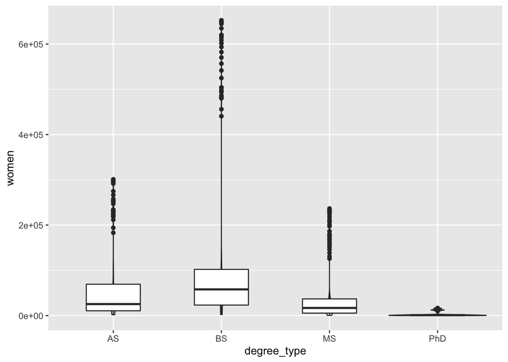

```r
ggplot(data)+
  geom_violin(mapping = aes(x = degree_type, y = women))+
  geom_boxplot(mapping = aes(x = degree_type, y = women), width = .5)
```